# ISLET solve function

Ziyi Ou

2024-10-17

```r
rm(list=ls())
setwd("/Users/ziyiou/CUHKSZ/23 Fall/Genomics/longitudinal analysis/2024.10.15/EM algorithm")
#library(GEOquery)
```

```r
library(SummarizedExperiment)
library(SingleCellExperiment)
library(GEOquery)
library(ISLET)
library(Seurat)
library(MuSiC)
library(dplyr)
library(ggplot2)
library(tidyr)
library(fgsea)
library(Matrix)
library(pheatmap)
library(stringr)
library(gridExtra)
library(reshape2)
library(biomaRt)
library(linseed)
library(DWLS)
library(FARDEEP)
library(MCMCpack)
library(PROPER)
library(edgeR)
library(MASS)
library(grid)
library(pROC)
library(ROCR)
library(DESeq2)
```

# 1. Parameter Estimation

```r
################ meta data ################
real_gene_count = readRDS("real_gene_count.rds")
real_pdata = readRDS("real_pdata.rds")

real_meta_data <- data.frame(group = ifelse(real_pdata$`diseasestatus:ch1` == "Healthy Control", "ctrl",
                      "case"),
                      subject_ID = as.numeric(real_pdata$`donorid:ch1`),
                      age = as.numeric(real_pdata$`age:ch1`),
                      cellType = real_pdata$`celltype:ch1`)
rownames(real_meta_data) <- real_pdata$geo_accession


# 去除细胞类型为"Whole Blood"的样本
filtered_meta_data <- subset(real_meta_data, cellType != "Whole Blood")
filtered_gene_count <- real_gene_count[colnames(real_gene_count) %in% rownames(filtered_meta_data), ]

# 确保行名的顺序匹配
filtered_gene_count <- filtered_gene_count[, rownames(filtered_meta_data)]


ctrl_meta_data <- subset(filtered_meta_data, group == "ctrl")
case_meta_data <- subset(filtered_meta_data, group == "case")

ctrl_gene_count <- filtered_gene_count[, rownames(ctrl_meta_data)]
case_gene_count <- filtered_gene_count[, rownames(case_meta_data)]

ctrl_gene_count <- ctrl_gene_count
################
```

We use `DESeq2` to do the parameter estimation.

We get the mean expression of gene and perform log translation to it, save it as `mu_m.rds`.

In the reference panel, we assume the mean expression of gene $g$ for subject $j$ at time follows $N(\mu _m, \sigma_m^2)$, where $\sigma_m$ is estimated by `estimateDispersions` function in `DESeq2`. We save it as `var_m.rds`.

```r
dds <- DESeqDataSetFromMatrix(countData = ctrl_gene_count,
                              colData = ctrl_meta_data,
                              design = ~ 1)
dds
```

```
## class: DESeqDataSet
## dim: 29920 24
## metadata(1): version
## assays(1): counts
## rownames(29920): FGR CFH ... LINC00662 IGHV3OR16-15
## rowData names(0):
## colnames(24): GSM1479438 GSM1479439 ... GSM1479524 GSM1479525
## colData names(4): group subject_ID age cellType
```

```r
dds1 <- DESeq(dds)
```

```
## -- replacing outliers and refitting for 96 genes
## -- DESeq argument 'minReplicatesForReplace' = 7
## -- original counts are preserved in counts(dds)
```

```r
res <- results(dds1)
res
```

```
## log2 fold change (MLE): Intercept
## Wald test p-value: Intercept
## DataFrame with 29920 rows and 6 columns
##               baseMean log2FoldChange     lfcSE      stat       pvalue
##              <numeric>      <numeric> <numeric> <numeric>    <numeric>
## FGR          857.34899        9.74374  0.443362  21.97692 4.78836e-107
## CFH            2.73618        1.45216  0.503580   2.88368  3.93055e-03
## FUCA2         17.96582        4.16718  0.312560  13.33243  1.49937e-40
## GCLC          20.26188        4.34070  0.189674  22.88500 6.55419e-116
## NFYA          82.97725        6.37464  0.164013  38.86666  0.00000e+00
## ...                ...            ...       ...       ...          ...
## CYP3A54P      0.000000             NA        NA        NA           NA
## LINC02164     0.000000             NA        NA        NA           NA
## TUBB8P7       0.127477      -2.971695  1.658891 -1.791375    0.0732332
## LINC00662     0.879693      -0.184927  0.347799 -0.531708    0.5949283
## IGHV3OR16-15  0.000000             NA        NA        NA           NA
##                      padj
##                 <numeric>
## FGR          1.38268e-106
## CFH           6.03569e-03
## FUCA2         3.13892e-40
## GCLC         1.96268e-115
## NFYA          0.00000e+00
## ...                   ...
## CYP3A54P               NA
## LINC02164              NA
## TUBB8P7         0.0841442
## LINC00662       0.6180206
## IGHV3OR16-15           NA
```

```r
dds <- estimateSizeFactors(dds)
dds <- estimateDispersions(dds)
```

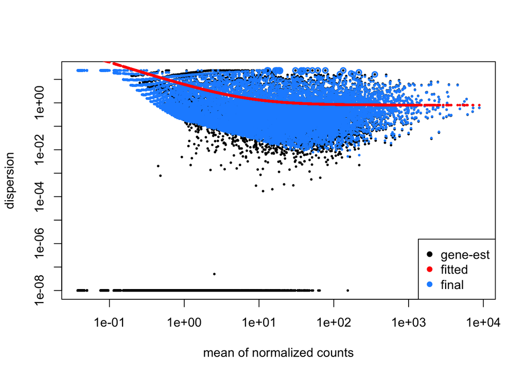

```r
plotDispEsts(dds)
```

```r
head(dispersions(dds))
```

```
## [1] 2.2654740 2.5637224 1.0715827 0.3661652 0.2982945 0.1984116
```

```r
mu_m <- data.frame(res$baseMean)
#mu_m <- log(mu_m)
rownames(mu_m) <- rownames(ctrl_gene_count)

dispersion_m <- data.frame(dispersions(dds))
rownames(dispersion_m) = rownames(dispersion_m)


# 标记 mu_m 中包含 -Inf 的行
non_inf_rows <- rowSums(mu_m == -Inf) == 0

# 标记 var_m 中包含 NA 的行
non_na_rows <- rowSums(is.na(dispersion_m)) == 0

# 取交集：同时满足 non_inf_rows 和 non_na_rows 的行
valid_rows <- non_inf_rows & non_na_rows
gene <- rownames(mu_m)[valid_rows]

# 筛选出 mu_m 和 var_m 中保留的行
mu_m_filtered <- mu_m[valid_rows, ]
dispersion_m_filtered <- dispersion_m[valid_rows, ]

mu_m <- data.frame(mu_m_filtered)
rownames(mu_m) = gene
mu_m <- head(mu_m, 5000)

dispersion_m <- data.frame(dispersion_m_filtered)
rownames(dispersion_m) = gene
dispersion_m <- head(dispersion_m, 5000)

var_m = 1/mu_m + dispersion_m
```

In `DESeq2`, variance $\sigma^2 = \mu + \alpha\mu^2$, here $\mu$ is mean and $\alpha$ is the dispersion. Since in the following simulation we simulate count in log scale, and by Taylor Expansion we know that $log(X) ≈ log(\mathbb{E}[X])+ \mathbb{E}[X] (X−\mathbb{E}[X])$, therefore $\mathrm{Var}[log(X)] = \displaystyle \frac{\mathrm{Var}[X]}{\mathbb{E}^2[X]}$

```r
saveRDS(log(mu_m), file="mu_m.rds")
saveRDS(dispersion_m, file = "dispersion_m.rds")
saveRDS(var_m, file = "var_m.rds")
```

```r
mu_m = readRDS("mu_m_500.rds")
mu_m = mu_m$mu_m_filtered
sigma_m = readRDS("var_m_500.rds")

cellType_list = c("B-cells", "CD4", "CD8", "NK", "Neutrophils", "Monocytes")
gene_list = rownames(sigma_m)
```

# 2. Temporal cell type proportions

We assume the proportion $\theta_{jt}$ of each subject $j$ for $K$ cell types at time $t$ follows Dirichlet distribution with parameter $\alpha$, where $\alpha$ and $\theta_{jt}$ are both $K \times 1$ vectors, $\mathbf{1}^T\theta_{jt} = 1$.

```r
################# Notation Setup #################

#### input ####
# J: number of subject (must be an even number)
# T: number of time point (must be an even number)
# alpha_ls: cell population composition parameters for Dirichlet dist.  (list(alpha_c, alpha_d))
# cell_ls: list of cell types

#### output ####
# theta: cell type proportion

#### This `Gen_prop` function is for generating cell type proportion

Gen_prop <- function(J, T, alpha_ls, cell_ls) {
  set.seed(123)
  alpha_c = alpha_ls[["alpha_c"]]  # Dirichilet distribution params for control group
  alpha_d = alpha_ls[["alpha_d"]]  # Dirichilet distribution params for case group

  ctrl_theta <- rdirichlet(n=J*T/2, alpha = alpha_c)
  case_theta <- rdirichlet(n=J*T/2, alpha = alpha_d)

  colnames(ctrl_theta) <- cell_ls
  colnames(case_theta) <- cell_ls
  rownames(case_theta) <- seq(from = 1, to = J * T / 2) # in accordance with sample_ID in metadata
  rownames(ctrl_theta) <- seq(from = J * T / 2 + 1, to = J * T)

  theta <- rbind(case_theta, ctrl_theta) # case is on the top

  return(theta = t(theta))
  # transpose: let theta be a n*K matrix (n is the number of samples)
}
```

In the paper, author provided us with the parameter value for the Dirichlet distribution:

$$\alpha_c = (8.85, 6.49, 5.98, 5.28,
4.22, 3.85)$$
$$\alpha_d = (1.90,
2.25, 2.10, 5.72, 7.33, 15.37)$$

```r
ctrl_alpha <- c(8.85, 6.49, 5.98, 5.28, 4.22, 3.85) # ctrl group
case_alpha <- c(1.90, 2.25, 2.10, 5.72, 7.33, 15.37) # case group
alpha_list = list(alpha_c = ctrl_alpha, alpha_d = case_alpha)

theta = Gen_prop(J=50, T=5, alpha_ls = alpha_list, cell_ls = cellType_list)
theta[, 1:5]
```

```
##                      1          2          3          4          5
## B-cells     0.02230079 0.01501410 0.01314183 0.04691058 0.04692466
## CD4         0.06623229 0.08058458 0.06463024 0.12883512 0.12880281
## CD8         0.07401944 0.05478895 0.14144167 0.03732913 0.10845406
## NK          0.14745136 0.11669351 0.20039315 0.18620546 0.17347204
## Neutrophils 0.30466902 0.20367899 0.21962805 0.28593910 0.24653747
## Monocytes   0.38532711 0.52923987 0.36076506 0.31478060 0.29580895
```

# 3. Individual reference panel and temporal gene expression

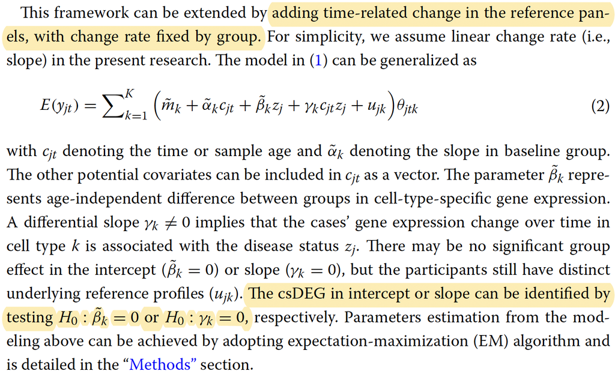

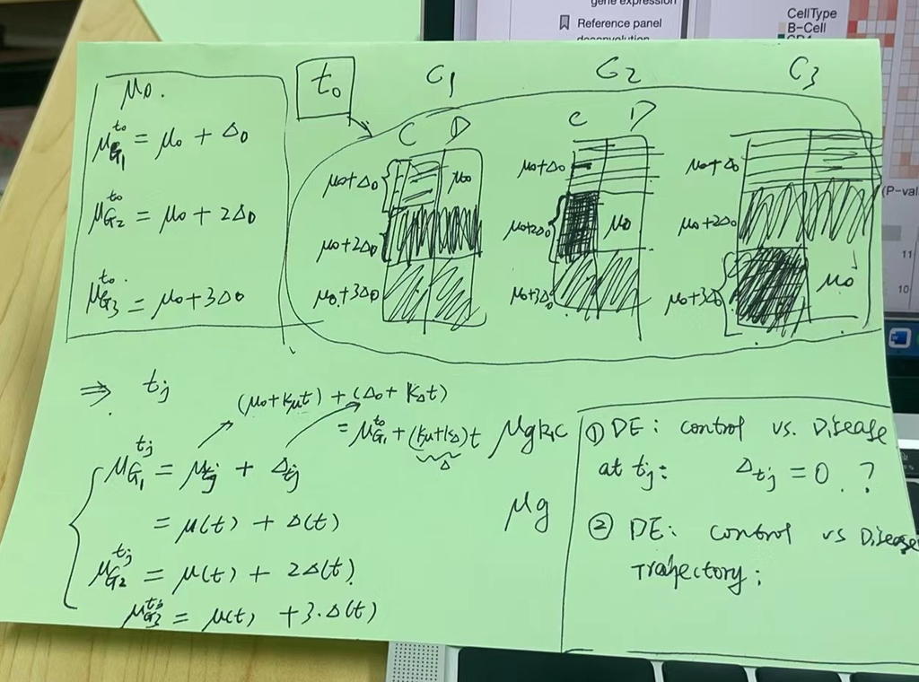

For gene $g$, the mean expression of cell type $k$ per subject $j$ at time $t$ is $M_{gjkt} \sim N(\mu^{t_j}_k, \sigma_g^2)$ ($\sigma_g$ is the overdispersion of each gene estimated by `DESeq2`).

The true reference matrix is $\lambda_{gjkt} \sim \Gamma(\mathrm{exp}(-\Phi_{gjk}), M_{gjkt}\mathrm{exp}(\Phi_{gjk}))$, where $M_{gjkt}$ and $\Phi_{gjk}$ are components in vector $\mathbf{M_{gjt}}, \mathbf{\Phi_{gj}}$, and $\mathrm{exp}(-\Phi_{gjk})$ is shape, $M_{gjkt}\mathrm{exp}(\Phi_{gjk})$ is scale. ($\Phi_{gjk} \sim N(-3, 1)$).

Note that $M_{gjkt}$ and $\Phi_{gjk}$ are both in **log** scale.

## (1) Main Function

```r
control_matrix <- function(cell_ls, gene_ls, DEG_ls, mu_jt, delta_jt) {
  G = length(gene_ls) # number of genes
  K = length(cell_ls)


  control <- matrix(0, nrow = G, ncol = K)
  colnames(control) = cell_ls
  rownames(control) = gene_ls

  for (k in 1:K) {
    deg_indices = DEG_ls[[cell_ls[k]]]$Type3
    control[deg_indices, ] = delta_jt  # k*delta_jt
  }

  control = control + mu_jt

  return(control)

}

case_matrix <- function(cell_ls, gene_ls, DEG_ls, mu_jt, delta_jt) {
  G = length(gene_ls) # number of genes
  K = length(cell_ls)


  case <- matrix(0, nrow = G, ncol = K)
  colnames(case) = cell_ls
  rownames(case) = gene_ls

  for (k in 1:K) {
    deg_indices = DEG_ls[[cell_ls[k]]]$Type3
    case[deg_indices, ] = delta_jt # k*delta_jt
    case[deg_indices, k] = 0
  }

  case = case + mu_jt

  return(case)

}
```

```r
################# Notation Setup #################

#### input ####
# J: number of subject (must be an even number)
# T: number of time point (must be an even number)
# mu_m
# sigma_m
# gene_ls: list of gene names
# cell_ls: list of cell types
# Delta_0 (LFC): age-independent group effect (intercept)
# k_mu: slope in baseline group
# k_delta: age-dependent group effect (slope)

#### output ####
# M: mean expression of gene
# Phi: overdispersion
# DEG_ls: list of differentially expressed genes (list(Type1, Type2, Type3))
# lambda: true reference expression
# meta_data

#### This `Gen_ref` function is for generating longitudinal individual reference panel

Gen_ref <- function(J, T, mu_m, sigma_m,
                       gene_ls, cell_ls, LFC=1.5, k_mu = 0.01, k_delta = 0.1) {
  set.seed(123)

  ### meta data
  meta_data <- data.frame(sample_ID = 1:(J*T),
                          group = rep(c("case", "ctrl"), each = T*J/2),
                          subject_ID = rep(1:J, each=T),
                          time_point = rep(1:T, J))



  ### marker gene index generation
  G = length(gene_ls) # number of genes
  K = length(cell_ls)

  sample_size <- ceiling(0.05 * G) # 5% DEG of each cell type
  DEG_ls <- setNames(vector("list", length(cell_ls)), cell_ls)

  for (k in 1:K) {

    DEG_ls[[cell_ls[k]]] = list(
      Type3 = seq(((k-1)*sample_size)+1, (k*sample_size))) }


  ### reference panel generation
  mu_m = matrix(rep(mu_m, times = K), nrow = G, ncol = K)
  rownames(mu_m) = gene_ls
  colnames(mu_m) = cell_ls

  sigma_m = data.frame(rep(sigma_m, each=K))
  rownames(sigma_m) = gene_ls
  colnames(sigma_m) = cell_ls

  ### Generate M
  M_ls = list()
  shift = ceiling(T/2)

  for  (j in (1:(J %/% 2))){
    mu_jt = mu_m
    delta_jt = LFC
    for (t in (1:T)) { # linear
      #if (t %in% (1:shift)) {mu_m_case = mu_m_case + Delta3}
      #else {mu_m_case = mu_m_case - Delta3}
      mu_jt = mu_jt + k_mu*t
      delta_jt = delta_jt + k_delta*t
      mu_m_case = case_matrix(cell_ls = cell_ls, gene_ls = gene_ls, DEG_ls = DEG_ls, mu_jt = mu_jt, delta_jt = delta_jt)
      M <- mapply(rnorm, n = 1, mean = mu_m_case, sd = sigma_m)
      M <- matrix(M, nrow = nrow(mu_m_case), ncol = ncol(mu_m_case),
             dimnames = dimnames(mu_m_case))

    # current idx: (j-1)*T + t
      M_ls[[as.character((j - 1) * T + t)]] <- M

   }
  }

  for  (j in (((J %/% 2)+1):J)){
    mu_jt = mu_m
    delta_jt = LFC
    for (t in (1:T)) {
      mu_jt = mu_jt + k_mu*t
      delta_jt = delta_jt + k_delta*t
      mu_m_ctrl = control_matrix(cell_ls = cell_ls, gene_ls = gene_ls, DEG_ls = DEG_ls, mu_jt = mu_jt, delta_jt = delta_jt)
      M <- mapply(rnorm, n = 1, mean = mu_m_ctrl, sd = sigma_m)
      M <- matrix(M, nrow = G, ncol = K,
             dimnames = dimnames(mu_m_ctrl))

    # current idx: (j-1)*T + t
      M_ls[[as.character((j - 1) * T + t)]] <- M

    }
  }

  ## Generate Phi
  Phi_ls = list()
  for (j in 1:J) {
    for (t in 1:T) {
    # 生成 Phi 矩阵
    Phi <- mapply(rnorm, n = G*K, mean = -3, sd = 1)
    Phi <- matrix(Phi, nrow = G, ncol = K,
             dimnames = dimnames(mu_m_ctrl))
    Phi_ls[[as.character((j - 1) * T + t)]] <- Phi }
    }

  ## Generate lambda
  lambda_ls = list()
  for  (j in (1:J)){
    for (t in (1:T)){
      idx = (j - 1) * T + t
      M = M_ls[[as.character(idx)]]
      Phi = Phi_ls[[as.character(idx)]]
      lambda <- matrix(nrow = nrow(M), ncol = ncol(M))

      shape_matrix <- exp(-Phi)
      rate_matrix <- 1 / (exp(M) * exp(Phi))

      lambda <- mapply(function(shape, rate) {
          if (shape <= 0 || rate <= 0) {
            return(0)} else {
    return(rgamma(n = 1, shape = shape, rate = rate))}},
    as.vector(shape_matrix), as.vector(rate_matrix))

      # reorganize lambda into a matrix
      lambda <- matrix(lambda, nrow = nrow(M), ncol = ncol(M))
      lambda[lambda > 20000] <- 20000
      colnames(lambda) = colnames(M)
      rownames(lambda) = rownames(M)

      lambda_ls[[as.character(idx)]] <- lambda
    }
  }


  return (list(DEG_ls = DEG_ls, M_ls = M_ls, Phi_ls = Phi_ls, lambda_ls=lambda_ls, meta_data = meta_data))
}
```

## (2) Heatmap Function

```r
create_heatmap_grob <- function(M, title, color_palette) {
  pheatmap_obj <- pheatmap(M,
                           cluster_rows = FALSE,
                           cluster_cols = FALSE,
                           show_rownames = FALSE,
                           show_colnames = TRUE,
                           color = colorRampPalette(c("blue", "white", "red"))(100),
                           main = title,
                           silent = TRUE)  # silent=TRUE 以避免直接打印

  grid_plot <- pheatmap_obj$gtable
  return(grid_plot)
}
```

# 4. Mixture-cell expression

The observed bulk RNA-seq raw counts for gene g in subject j measured at time point t is generated from Poisson distribution $Y_{gjt} \sim Pois(\tilde{\lambda}_{gjt})$, where $\tilde{\lambda}_{gjt} = \lambda_{gtj}^T\theta_{gjt}$, $\lambda_{gtj}^T = (\lambda_{gjt1}, ..., \lambda_{gjtK})$

```r
################# Notation Setup #################

#### input ####
# lambda_ls: cell-type-specific reference
# theta: cell-type proportion

#### output ####
# Y: bulk RNA-seq raw counts

#### This `Gen_mix` function is for generating mixture-cell expression

Gen_mix <- function(lambda_ls, theta) {
  n = length(lambda_ls) # the number of samples (J*T)
  G = nrow(lambda_ls[[1]]) # the number of genes
  K = ncol(lambda_ls[[1]]) # the number of cell types

  Y = matrix(nrow = G, ncol = n)

  for (i in 1:n) {
    mean_value = lambda_ls[[i]] %*% theta[, i]
    Y[, i] = rpois(G, lambda = mean_value)
  }

  colnames(Y) = colnames(theta)
  rownames(Y) = rownames(lambda_ls[[1]])

  return (Y = Y)
}
```

# 5. Solve function

## 5.1 utils function

```r
###function to obtain sum of squares
ss<-function(x){
  a<-sum(x^2)
  return(a)
}

###function to obtain sum of squares
colss<-function(x){
    a<-colSums(x^2)
    return(a)
}

###function to make the design matrix [A] for random effect
#updated on 05/31/2022 to reflect the change in ID order
#user should sort their data by subject ID
#makea <- function(onectprop, ind_id = sub_id, datX = X, aNU = NU){
makea <- function(onectprop, ind_id, datX , aNU){
   lp <- split(onectprop, ind_id)
  a1 <- matrix(0, nrow=nrow(datX), ncol=aNU)
#  ct_sub=table(sub_id)[as.character(unique(sub_id))]
#  lp=lp[names(ct_sub)]
  chk <- unique(ind_id) #chk should have the length of NU
  lp<-lp[as.character(chk)]
  count <- rep(0, length(chk))
  for(i in seq_len(aNU)){
    tmp <- sum(ind_id == chk[i])
    count[i] <- tmp
  }

  for(i in seq_len(aNU)){
    s <- 1+sum(count[0:(i-1)])
    e <- sum(count[seq_len(i)])
    a1[s:e, i] <- lp[[i]]
  }
  return(a1)
}


LRT<-function(llk_f, llk_0, df){
    test.stat<-llk_f-llk_0
    p<-pchisq(as.numeric(test.stat), df, lower.tail=FALSE)
    return(p)
}


#clexp<-function(){
#    #clusterExport(cl, list('colss'))
#    clusterEvalQ(cl,  {
#        library(Matrix)})
#}



### imply add
# used for lme formulation set-up
lme_fml <- function(prop.i){
  cell_type_columns <- colnames(prop.i)
  prop_gp_columns <- paste0("Prop.gp.", cell_type_columns)
  formula_str <- "y ~ 0"
  for (i in seq_along(cell_type_columns)) {
    formula_str <- paste0(formula_str," + ", cell_type_columns[i], " + (0 + ",
                          cell_type_columns[i], " | subject_ID)")
  }
  formula_str <- paste0(formula_str, " + ",
                        paste(prop_gp_columns, collapse = " + "))
  return(formula_str)
}

lmer_deconv <- function(i,RNAseq_final_count,input,N.total,K,formula_str){
  y <- as.matrix(RNAseq_final_count)[i,] # fit for each gene independently
  input <- cbind(input, y)

  control <- lmerControl( check.conv.singular = "ignore")
  res <- lmer(formula = formula_str, data = input, control = control)
  re <- ranef(res)$subject_ID
  feout <- fixef(res)
  fe <- matrix(rep(feout,each=N.total),nrow=N.total)
  colnames(fe) <- names(feout)
  outcome_nodup <- unique(subset(input,select = c(2:1)))
  re <- re[match(outcome_nodup$subject_ID, rownames(re)),]
  #pull out main effect
  ref_pred_main <- fe[,seq_len(K)]+re
  #pull out interaction; some columns might drop out due to rank dificiency;
  #therefore need further manipulation
  ref_pred_intact <- fe[,-(seq_len(K))]*outcome_nodup$group
  intact.name <- strsplit(colnames(ref_pred_intact), "[.]")
  colnames(ref_pred_intact) <- vapply(intact.name, tail,
                                      FUN.VALUE = character(1), n = 1)

  #add up main and interaction coeeficients
  ref_pred <- ref_pred_main
  mcol <- match(colnames(ref_pred_intact),colnames(ref_pred_main))
  ref_pred[,mcol] <- ref_pred[,mcol]+ref_pred_intact

  ref_pred[ref_pred < 0] <- 0
  return(as.data.frame(ref_pred))
}
```

## 5.2 islet.est

```r
###function to implement EM algorithm by block of genes in ISLET algorithm
#function here for unix and windows, using lapply, no parallel computing
#Y is a GxN matrix for gene expression
islet.solve.block.revise <-function(Y, datuse){
    #exp_case = as.matrix(datuse@exp_case)
    #exp_ctrl = as.matrix(datuse@exp_ctrl)
    X <- datuse@X
    A <- datuse@A
    K <- datuse@K
    NU <- datuse@NU
    NS <- datuse@NS
#    para<-datuse@para

    #initialization of parameters parameter estimation storage
    B_est<-NULL
    Sig0_est <- NULL
    SigU_est <- NULL
    E_U_est <- NULL
    llk <- NULL
    ##
    Y<-t(Y)
    G<-ncol(Y)
    #  Y=log2(Y+1)

    ####1. Initialization of parameters
    #1.1 cell type profiles AND csDE B parameters
    #B_0 = solve(X,Y)
    B_0 <- Matrix::tcrossprod( Matrix::tcrossprod(solve( Matrix::crossprod(X)), X), t(Y))

    #1.2 error terms
    # sig <- mean((Y-X%*%B_0)^2)
    sig <- colMeans((Y-X%*%B_0)^2)
    #sig <- 20

    #1.3 missing values
    U_0 <- rep(0, NU*K)

    B_t <- B_0
    #sig_t = rep(sig, 7)
    U_t <- U_0
    #sig0_t <- rep(sig, G)
    #sigK_t <- rep(sig, K)
    sig0_t <- sig #rep(sig, G)
    sigK_t <- matrix(rep(sig, each=K), nrow=K)

    iem <- 1
    diff1 <- 100
    B_change_val <- 100
    diff2 <- 100
    pp <- 1

    #Sig_U = diag(rep(sigK_t, each = NU))
    Sig_p<-lapply(seq_len(G), function(x, A, sig0_t, sigK_t, NU, Y, X, B_t){
        invSig_U<-Matrix::bdiag(diag(rep(1/sigK_t[, x], each=NU)))
        Sig<-solve( Matrix::crossprod(A)/sig0_t[x]+invSig_U)
        U<- Matrix::tcrossprod( Matrix::tcrossprod(Sig, A),
                                BiocGenerics::t(Y[, x] - Matrix::tcrossprod(X,
                               BiocGenerics::t(B_t[, x])))
                               )/sig0_t[x]
        return(list(Sig=Sig, U=U))
    }, A, sig0_t, sigK_t, NU, Y, X, B_t)
    E_Up<-do.call(cbind, lapply(Sig_p, function(x)x$U))

    tolerance_diff1 <- 1e-5
    tolerance_diff2 <- 1e-5
    max_iterations <- 500

    while(iem <= max_iterations && (B_change_val > tolerance_diff1 || diff2 > tolerance_diff2)){
#        cat("iteration=", iem, "\n")
        iem <- iem + 1
        ####2. E-step
        #observed data COV(Y) = V

        #V = A%*%Sig_U%*%t(A) + diag(rep(sig0_t, 5*600))

        #2.1 E[U|Y]: missing data [U|Y] given observed data
        #invV = solve(V)
        # E_U = mu_p = t(Sig_U) %*% t(A) %*% invV %*% (Y - X %*% B_t)
        # Sig_p = Sig_U - crossprod(Sig_U,t(A)) %*% invV %*% A %*% Sig_U

        # Estimate from last iteration

        E_U <- E_Up
        mu_p <- E_Up
        E_U_frame <- as.data.frame(as.matrix(E_U))
        #2.2 E[t(S)S|Y]
        E_StS <- lapply(seq_len(G), function(x, A, Sig_p, mu_p, X, B_t, Y){
           sum( Matrix::diag(Matrix::tcrossprod( Matrix::tcrossprod(A, Sig_p[[x]]$Sig), A))) +
                sum(( Matrix::tcrossprod(A, BiocGenerics::t(mu_p[, x])) +
                          Matrix::tcrossprod(X, BiocGenerics::t(B_t[, x])) - Y[, x])^2)},
           A, Sig_p, mu_p, X, B_t, Y)
        E_StS <-unlist(E_StS)

        #2.3 E[U_k^T U_k|Y]
        mutra_split <- lapply(Sig_p, function(x){
            sig_p<-split(diag(x$Sig), ceiling(seq_len(NU*K)/NU))
            tra<-unlist(lapply(sig_p, sum))
            return(tra)
        })
        mu_split <- split(E_U_frame, ceiling(seq_along(E_U_frame[, 1])/NU))

        E_UkTUk <- do.call('cbind', mutra_split) + do.call('rbind', lapply(mu_split, colss))

        ####3. M-step
        #3.1 B
        B_tp <-  Matrix::tcrossprod( Matrix::tcrossprod(solve( Matrix::crossprod(X)), X),
                                     BiocGenerics::t(Y- Matrix::tcrossprod(A, BiocGenerics::t(E_U))) )

        #make correction in case B[1:K]<0 or B_tp[(K+1):2K]<0
        #important to bound the estimation to positive values

        # B_tp[1:K,]=ifelse(B_tp[1:K,]<0,0,B_tp[1:K,])
        # B_tp[-(1:K),]=ifelse(B_tp[1:K,]+B_tp[-(1:K),]<0,-B_tp[1:K,],B_tp[-(1:K),])

        #3.2 sigma_0^2
        sig0_tp <- E_StS/(NS)

        #3.3 sigma_k^2
        sigK_tp <- E_UkTUk/(NU)

        ####4. Stopping criteria
        diff1 <- sum(abs(B_tp - B_t)) + abs(sig0_tp - sig0_t) + sum(abs(sigK_tp - sigK_t))
        #cat("Fixed effect diff1=", diff1, "\n") #


        n1 <- sum(abs(B_tp - B_t))/length(B_tp)
        n2 <- sum(abs(B_tp))/length(B_tp)
        pp <- n1/n2
#        cat("B_sum_val=", n2, "\n")
#        cat("B_change_val=", n1, "\n")
#        cat("B_change_prop=", pp*100,"% \n")

        ####5. Update params
        B_t<-B_tp
        sig0_t <- sig0_tp
        sigK_t <- sigK_tp

        Sig_p<-lapply(seq_len(G), function(x, A, sig0_t, sigK_t, NU, Y, X, B_t){
            Sig_U<- Matrix::bdiag(diag(rep(sigK_t[, x], each=NU)))
            invSig_U<-Matrix::bdiag(diag(rep(1/sigK_t[, x], each=NU)))
            Sig<-solve( Matrix::crossprod(A)/sig0_t[x]+invSig_U)
            U<- Matrix::tcrossprod(Matrix::tcrossprod(Sig, A),
                                   t(as.matrix(Y[, x] -
                                    Matrix::tcrossprod(X, BiocGenerics::t(B_t[, x]))))
                                   )/sig0_t[x]
            return(list(Sig_U=Sig_U, Sig=Sig, U=U))
        }, A, sig0_t, sigK_t, NU, Y, X, B_t)
        Sig_p_all<-NULL
        E_Up<-do.call(cbind, lapply(Sig_p, function(x)x$U))

        diff2 <- sum(abs(E_Up - E_U))/length(E_U) #*mean(colMeans(Y))^2)
       # cat("Random effect diff2=", diff2, "\n") #

    }
    # Estimate of fixed effect
    B_est<-cbind(B_est, B_t)
    # Estimate of random effect
    E_U_est<-cbind(E_U_est, E_Up)
    # Estimate of variance Sigma_U,  Sigma_0
    Sig0_est <- cbind(Sig0_est, sig0_t)
    SigU_est <- cbind(SigU_est, sigK_t)

    #calculate LLK
    llk<-lapply(seq_len(G), function(x){
        Sig<- Matrix::tcrossprod( Matrix::tcrossprod(A, Sig_p[[x]]$Sig_U),  A)+
            Matrix::bdiag(diag(sig0_t[x], nrow = nrow(A)))
        l<- Matrix::determinant(Sig)$modulus+
            Matrix::tcrossprod(Matrix::crossprod(Y[, x]-
                      Matrix::tcrossprod(X, BiocGenerics::t(B_t[, x])), solve(Sig)),
                      BiocGenerics::t(Y[, x]-
                           Matrix::tcrossprod(X, BiocGenerics::t(B_t[, x]))) )
        return(-as.numeric(l))
    })

    llk<-unlist(llk)

    #compile return list
    case.m <- B_est[seq_len(K), ]+B_est[K+seq_len(K), ]
    ctrl.m <- B_est[seq_len(K), ]

    #(2) the individual value for case and control, for all cell types. 2 matrices of NU by K.
    rel <- split(as.data.frame(as.matrix(E_U_est)), ceiling(seq_along(E_U_est[, 1])/NU))

    case.u <- lapply(seq_len(K), function(k){rel[[k]][seq_len(datuse@case_num), ]})
    ctrl.u <- lapply(seq_len(K), function(k){rel[[k]][seq_len(datuse@case_num), ]})
    names(case.u) <- names(rel)
    names(ctrl.u) <- names(rel)

    case.indv <- lapply(seq_len(K), function(k){rel[[k]][seq_len(datuse@case_num), ] +
            matrix(rep(case.m[k, ], each=datuse@case_num), nrow=datuse@case_num)})
    ctrl.indv <- lapply(seq_len(K), function(k){rel[[k]][-seq_len(datuse@case_num), ] +
            matrix(rep(ctrl.m[k, ], each=datuse@ctrl_num), nrow=datuse@ctrl_num)})
    names(case.indv) <- names(rel)
    names(ctrl.indv) <- names(rel)

    #(3) Variance for K cell types. 1 vector of length K.
    #'SigU_est' is already to be rendered.

    #(4) Variance for grand residuals. 1 scalar.
    #'Sig0_est' is already to be rendered.

    #(5) the model likelihood. 1 scalar.
    #'llk' is already to be rendered.
    #'
    cat("iteration=", iem, "\n")
    cat("B_change_val:", B_change_val, "\n")
    cat("U_change_val:", diff2, "\n")

    #compile return list
    rval <- list(
        case.m=case.m,
        ctrl.m=ctrl.m,
        case.indv=case.indv,
        ctrl.indv=ctrl.indv,
        var.k=SigU_est,
        var.0=Sig0_est,
        LLK=llk,
        rel = rel,
        case.u = case.u,
        ctrl.u = ctrl.u)
    return(rval)

    message("Complete: parameter estimation from ISLET is complete.")
}
```

## 5.3 islet.solve

```r
###function to run ISLET, using parallel computing

isletSolve.revise <-function(input, BPPARAM=bpparam() ){
    # islet.solve only runs on the model without age effect.
    if(input@type == 'slope'){
        stop('Input should be prepared by dataPrep()')
    }

    #make Yall a list
    G <- nrow(input@exp_case)
    Yall<-as.matrix(cbind(input@exp_case, input@exp_ctrl))
    aval.nworkers<-BPPARAM$workers
    block.size<-max(ceiling(G/aval.nworkers), 5)
    Yall.list <- split(as.data.frame(Yall), ceiling(seq_len(G)/block.size))

#    if(.Platform$OS.type == "unix") {
    ## do some parallel computation under Unix
#        multicoreParam <- MulticoreParam(workers = ncores)
      res <- bplapply(X=Yall.list, islet.solve.block.revise, datuse=input, BPPARAM=BPPARAM)
      return(res)}
#  }
#  else {
    ## This will be windows
    ## Use serial param or do not use any parallel functions, just use ‘lapply’
    ## result should be of the same “type” from both the if and else statements.
#    nworkers<-length(Yall.list)
#    cl <- makeCluster(nworkers)

    ## Remove clusterExport(), clusterEvalQ() if use devtools::install() to build package
#    clusterExport(cl,list('colss'))
#    clusterEvalQ(cl,{
#        library(Matrix)
#        library(BiocGenerics)})

#    res <-parLapply(cl, X=Yall.list, islet.solve.block, datuse=input)
#    stopCluster(cl)
#
#  }
```

## 5.4 example

```r
ref = Gen_ref(J=50, T=5, mu_m = mu_m, sigma_m = sigma_m,
                       gene_ls = gene_list, cell_ls = cellType_list, LFC=0.5,
              k_mu = 0.01, k_delta = 0.1)

meta_data <- ref$meta_data
lambda_list <- ref$lambda_ls
M_list <- ref$M_ls
Phi_list <- ref$Phi_ls
DEG_list <- ref$DEG_ls

head(meta_data)
```

```
##   sample_ID group subject_ID time_point
## 1         1  case          1          1
## 2         2  case          1          2
## 3         3  case          1          3
## 4         4  case          1          4
## 5         5  case          1          5
## 6         6  case          2          1
```

```r
Y <- Gen_mix(lambda_ls = lambda_list, theta = theta)

theta_df = as.data.frame(t(theta))

sample_info <- data.frame(group = meta_data$group,
                          subject_ID = meta_data$subject_ID,
                          #age = meta_data$time_point,
                          'B-cells' = theta_df$`B-cells`,
                          'CD4' = theta_df$CD4,
                          'CD8' = theta_df$CD8,
                          'NK' = theta_df$NK,
                          'Neutrophils' = theta_df$Neutrophils,
                          'Monocytes' = theta_df$Monocytes)
colnames(sample_info)[which(colnames(sample_info) == "B.cells")] <- "B-cells"

N25_se <- SummarizedExperiment(
    assays = list(counts = as.data.frame(Y)),
    colData = sample_info)

test_input <- dataPrep(dat_se = N25_se)
```

```
## Begin: working on data preparation as the input for ISLET algorithm.
```

```
## Complete: data preparation for ISLET.
```

```r
execution_time <- system.time({
res = isletSolve.revise(input = test_input)
})

print(execution_time)
saveRDS(res, "res_500_iterations.rds")
```

```r
res = readRDS("res_500_iterations.rds")

  # Organize estimated individual reference
input = test_input
  K<-input@K
  SubjectID<-unique(input@SubjectID)
  case_num<-input@case_num
  case.indv.merge<-lapply(seq_len(K), function(k){
      case.indv.all<-lapply(res, '[[', 3)
      case.indv.ctk<-t(do.call(cbind, lapply(case.indv.all, '[[', k)))
      case.indv.ctk<-ifelse(as.matrix(case.indv.ctk)<0, 0, case.indv.ctk)
      dimnames(case.indv.ctk)<-list(rownames(input@exp_case), SubjectID[seq_len(case_num)])
      return(case.indv.ctk)
  })
  ctrl.indv.merge<-lapply(seq_len(K), function(k){
      ctrl.indv.all<-lapply(res, '[[', 4)
      ctrl.indv.ctk<-t(do.call(cbind, lapply(ctrl.indv.all, '[[', k)))
      ctrl.indv.ctk<-ifelse(as.matrix(ctrl.indv.ctk)<0, 0, ctrl.indv.ctk)
      dimnames(ctrl.indv.ctk)<-list(rownames(input@exp_ctrl), SubjectID[-seq_len(case_num)])
      return(ctrl.indv.ctk)
  })

  case.u.merge<-lapply(seq_len(K), function(k){
      case.u.all<-lapply(res, '[[', 9)
      case.u.ctk<-t(do.call(cbind, lapply(case.u.all, '[[', k)))
      #case.u.ctk<-ifelse(as.matrix(case.u.ctk)<0, 0, case.u.ctk)
      dimnames(case.u.ctk)<-list(rownames(input@exp_case), SubjectID[seq_len(case_num)])
      return(case.u.ctk)
  })

  ctrl.u.merge <- lapply(seq_len(K), function(k){
      ctrl.u.all<-lapply(res, '[[', 10)
      ctrl.u.ctk<-t(do.call(cbind, lapply(ctrl.u.all, '[[', k)))
      #ctrl.u.ctk<-ifelse(as.matrix(ctrl.u.ctk)<0, 0, ctrl.u.ctk)
      dimnames(ctrl.u.ctk)<-list(rownames(input@exp_ctrl), SubjectID[-seq_len(case_num)])
      return(ctrl.u.ctk)
  })

    case.b.merge <- lapply(seq_len(K), function(k) {
  # 获取 case.indv 和 case.u 的矩阵
  case.indv <- case.indv.merge[[k]]
  case.u <- case.u.merge[[k]]

  # 计算差值，并确保没有负值
  case.diff <- case.indv - case.u

  return(case.diff)
})

    ctrl.b.merge <- lapply(seq_len(K), function(k) {
  # 获取 case.indv 和 case.u 的矩阵
  ctrl.indv <- ctrl.indv.merge[[k]]
  ctrl.u <- ctrl.u.merge[[k]]

  # 计算差值，并确保没有负值
  ctrl.diff <- ctrl.indv - ctrl.u

  return(ctrl.diff)
})

b.matrix <- lapply(seq_len(K), function(k) {
  # 获取 case.indv 和 case.u 的矩阵
  case.b <- case.b.merge[[k]]
  ctrl.b <- ctrl.b.merge[[k]]

  # 计算差值，并确保没有负值
  b.diff <- case.b - ctrl.b

  return(b.diff)
})



  names(case.indv.merge)<-input@CT
  names(ctrl.indv.merge)<-input@CT
  names(case.u.merge)<-input@CT
  names(ctrl.u.merge)<-input@CT
  names(case.b.merge)<-input@CT
  names(ctrl.b.merge)<-input@CT
  names(b.matrix)<-input@CT
  llk<-unlist(lapply(res, '[[', 7))


outputSol <- setClass("outputSol", slots=c(case.ind.ref="list",
                                           ctrl.ind.ref="list",
                                           mLLK="numeric",
                                           case.u.ref = "list",
                                           ctrl.u.ref = "list",
                                           case.b.ref = "list",
                                           ctrl.b.ref = "list"
                                           )
                      )

  rval<-outputSol(case.ind.ref=case.indv.merge,
            ctrl.ind.ref=ctrl.indv.merge,
            mLLK=llk,
            case.u.ref = case.u.merge,
            ctrl.u.ref = ctrl.u.merge,
            case.b.ref = case.b.merge,
            ctrl.b.ref = ctrl.b.merge)

#saveRDS(rval, file = "rval_5000.rds")
```

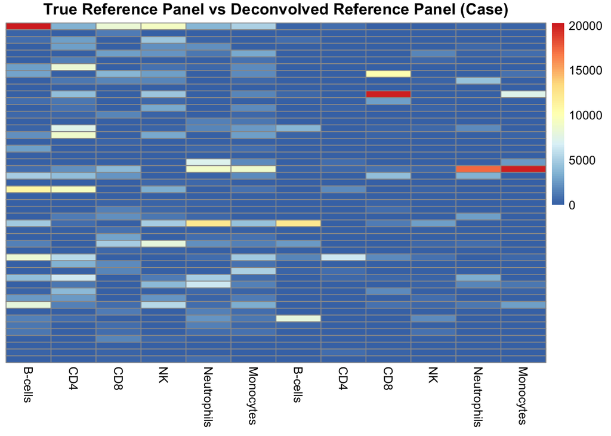

```r
N25_age.ref <- rval
caseVal <- caseEst(N25_age.ref)
ctrlVal <- ctrlEst(N25_age.ref)

lambda_list_islet <- list()

for (i in 1:50) {
  if (i %in% seq(1,25)) {
    Bcell = caseVal[["B-cells"]][,i]
    CD4 = caseVal[["CD4"]][,i]
    CD8 = caseVal[["CD8"]][,i]
    NK = caseVal[["NK"]][,i]
    Neutrophils = caseVal[["Neutrophils"]][,i]
    Monocytes = caseVal[["Monocytes"]][,i]
    lambda = t(rbind(Bcell, CD4, CD8, NK, Neutrophils, Monocytes))
    colnames(lambda) = c("B-cells","CD4", "CD8",  "NK", "Neutrophils", "Monocytes")

    lambda_list_islet[[as.character(i)]] <- lambda

  }

  else {
    Bcell = ctrlVal[["B-cells"]][,i-25]
    CD4 = ctrlVal[["CD4"]][,i-25]
    CD8 = ctrlVal[["CD8"]][,i-25]
    NK = ctrlVal[["NK"]][,i-25]
    Neutrophils = ctrlVal[["Neutrophils"]][,i-25]
    Monocytes = ctrlVal[["Monocytes"]][,i-25]
    lambda = t(rbind(Bcell, CD4, CD8, NK, Neutrophils, Monocytes))
    colnames(lambda) = c("B-cells","CD4", "CD8",  "NK", "Neutrophils", "Monocytes")

    lambda_list_islet[[as.character(i)]] <- lambda
  }
}

true_ref_case <- lambda_list_islet[[1]][1:50, ]
islet_ref_case <- lambda_list[[1]][1:50, ]
ref_case_combined <- cbind(true_ref_case, islet_ref_case)
pheatmap(ref_case_combined,
         cluster_rows = FALSE,  # 关闭行聚类
         cluster_cols = FALSE,  # 关闭列聚类
         show_rownames = FALSE,  # 不显示行名
         show_colnames = TRUE,
         main = "True Reference Panel vs Deconvolved Reference Panel (Case)")  # 显示列名
```

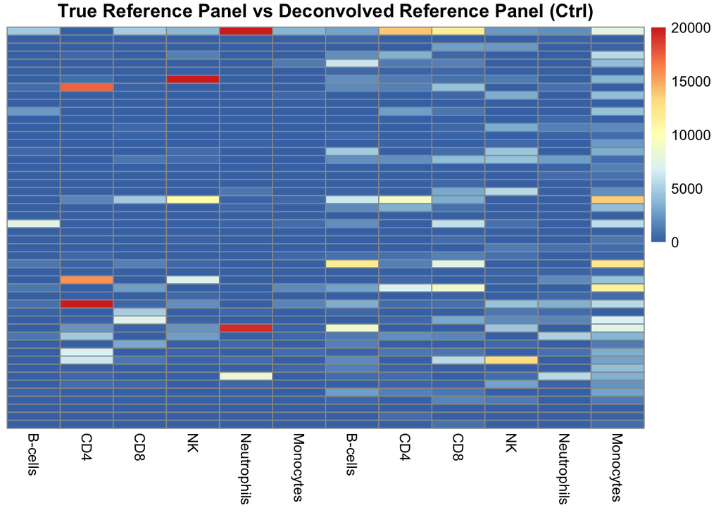

```r
true_ref_ctrl <- lambda_list[[126]][1:50, ]
islet_ref_ctrl <- lambda_list_islet[[26]][1:50, ]
ref_ctrl_combined <- cbind(true_ref_ctrl, islet_ref_ctrl)
pheatmap(ref_ctrl_combined,
         cluster_rows = FALSE,  # 关闭行聚类
         cluster_cols = FALSE,  # 关闭列聚类
         show_rownames = FALSE,  # 不显示行名
         show_colnames = TRUE,
         main = "True Reference Panel vs Deconvolved Reference Panel (Ctrl)")  # 显示列名
```

```r
true_ref_case <- lambda_list[[1]]
islet_ref_case <- lambda_list_islet[[1]]
overall_correlation <- cor(c(true_ref_case), c(islet_ref_case))
print(paste("Correlation of case:", overall_correlation))
```

```
## [1] "Correlation of case: 0.170919741278682"
```

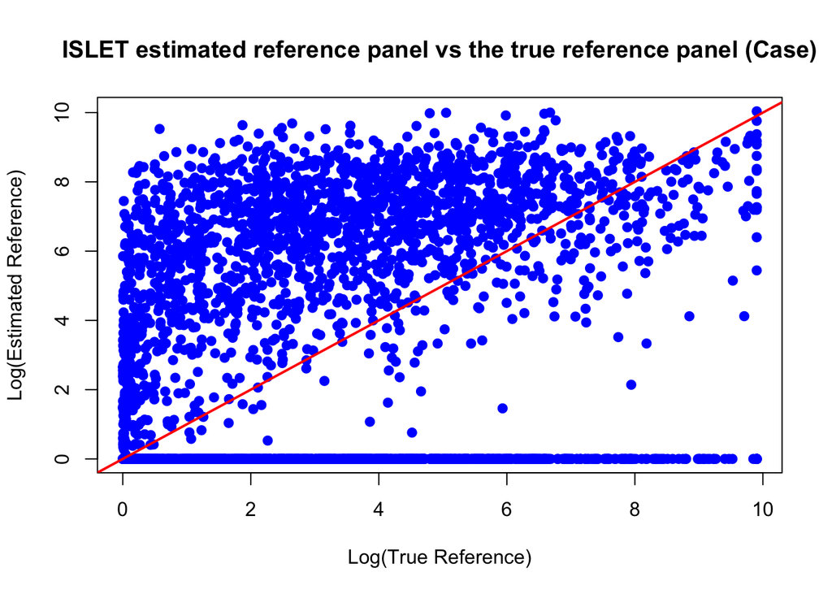

```r
plot(c(log(true_ref_case+1)), c(log(islet_ref_case+1)), # +1 to avoid -Inf
     main="ISLET estimated reference panel vs the true reference panel (Case)",
     xlab="Log(True Reference)",
     ylab="Log(Estimated Reference)",
     pch=19,
     col="blue")

abline(a=0, b=1, col="red", lwd=2)
```

```r
true_ref_ctrl <- lambda_list[[126]]
islet_ref_ctrl <- lambda_list_islet[[26]]
overall_correlation <- cor(c(true_ref_ctrl), c(islet_ref_ctrl))
print(paste("Correlation of ctrl:", overall_correlation))
```

```
## [1] "Correlation of ctrl: 0.21192280101139"
```

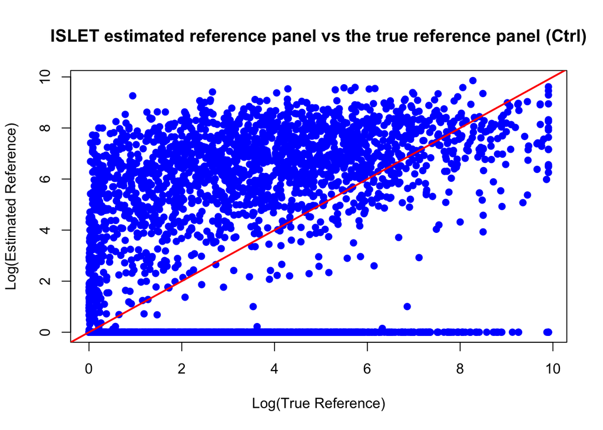

```r
plot(c(log(true_ref_ctrl+1)), c(log(islet_ref_ctrl+1)),
     main="ISLET estimated reference panel vs the true reference panel (Ctrl)",
     xlab="Log(True Reference)",
     ylab="Log(Estimated Reference)",
     pch=19,
     col="blue")

abline(a=0, b=1, col="red", lwd=2)
```

# 6. Without `U`: solve regression

```r
test_input <- dataPrep(dat_se = N25_se)
```

```
## Begin: working on data preparation as the input for ISLET algorithm.
```

```
## Complete: data preparation for ISLET.
```

```r
#X_matrix = test_input@X
X_matrix = as.matrix(test_input@X)
Y_matrix = t(as.matrix(Y))



execution_time <- system.time({
B_matrix = Matrix::tcrossprod( Matrix::tcrossprod(solve( Matrix::crossprod(X_matrix)), X_matrix), t(Y_matrix))
})

print(execution_time)
```

```
##    user  system elapsed
##   0.004   0.000   0.004
```

```r
solved_mu_m_ctrl = t(B_matrix[1:6, ])
solved_mu_m_ctrl[solved_mu_m_ctrl < 0] <- 0

solved_mu_m_case = t(B_matrix[1:6, ]) + t(B_matrix[7:12, ])
solved_mu_m_case[solved_mu_m_case < 0] <- 0

true_ref_case <- exp(1/5*(M_list[[1]] + M_list[[2]] + M_list[[3]] + M_list[[4]] + M_list[[5]]))
overall_correlation <- cor(c(true_ref_case), c(solved_mu_m_case))
print(paste("Correlation of case:", overall_correlation))
```

```
## [1] "Correlation of case: 0.319730219843806"
```

```r
true_ref_case <- exp(1/5*(M_list[[126]] + M_list[[127]] + M_list[[128]] + M_list[[129]] + M_list[[130]]))
overall_correlation <- cor(c(true_ref_ctrl), c(solved_mu_m_ctrl))
print(paste("Correlation of ctrl:", overall_correlation))
```

```
## [1] "Correlation of ctrl: 0.208507548471507"
```